# VSE Simulation — standalone notebook

This notebook reproduces the **Voter Satisfaction Efficiency (VSE)** simulation methodology from the [`vse-sim`](https://github.com/electionscience/vse-sim) project for five voting systems — Plurality, Approval, IRV, STAR, and Condorcet (Schulze only; Ranked Pairs is dropped) — and extends it with three new sources of realistic voter degradation (epistemic noise, unfamiliarity, and ballot fatigue) and two new top-2 runoff hybrid methods (Approval Top-2 and Plurality Top-2).

## How this notebook is organized

The notebook proceeds in four parts: **(1)** a vendored, unmodified copy of the `vse-sim` methodology and the five baseline voting methods (Section 1); **(2)** the three new degradation mechanisms — epistemic noise and participation friction (unfamiliarity + ballot fatigue) — plus the two new top-2 runoff hybrid methods (Approval Top-2 and Plurality Top-2, each simulated with a Groggy and a Clear-Eyed runoff variant); **(3)** the simulation loop, baseline results, and a sanity check against `vse-sim`'s own published numbers; **(4)** the sweeps and diagnostics that produce this notebook's findings — individual and joint parameter sweeps, the runoff information-quality sweep, and the per-election runoff-betrayal diagnostic.

> The original single-file notebook is still here as [`vse_simulation.ipynb`](https://github.com/eigentaylor/eigentaylor.github.io/blob/main/assets/jupyter/vse_simulation.ipynb), unchanged.

## 1. The simulation code

Everything that runs an election lives in **`vse_sim/`**, next to this notebook, rather than in the notebook itself. It is plain Python you can read, grep, diff and run:

[output not shown]

### Reproducing this

```
    cd assets/jupyter
    pip install -r ../../requirements.txt
    python -m vse_sim.run --stage all      # recompute everything from the seed
    python -m vse_sim.run --verify         # check it reproduces what is committed
```

`--verify` re-runs every stage and compares content hashes against `vse_sim/results/`. Each stage is seeded from the single `SEED` in `config.py` and depends on no other stage, so you should get the same numbers, bit for bit. If you don't, that is a bug worth reporting.

### Checking it

```
python -m pytest vse_sim/tests/
```

`tests/test_parity.py` and `tests/test_sweeps_parity.py` run the original [`vse_simulation.ipynb`](https://github.com/eigentaylor/eigentaylor.github.io/blob/main/assets/jupyter/vse_simulation.ipynb) -- which is still in this repository, unchanged -- side by side with this package over identical electorates and require every number to match exactly. `tests/test_sanity.py` carries the mechanism checks that used to sit inline in sections 2, 3 and 4.

```python
# Everything below reads results that were computed once and stored. No election is
# simulated here: `context.load()` reads `vse_sim/results/*.json`, checks each one against
# the parameters in `vse_sim/config.py`, and raises if they no longer match -- so this
# notebook can never render numbers from before a parameter changed.
#
# To (re)compute the results, from `assets/jupyter/`:
#     python -m vse_sim.run --stage all      # the canonical run
#     python -m vse_sim.run --verify         # re-run and check it reproduces exactly
#     python -m vse_sim.run --list           # what is stored, and whether it is current
import pathlib
import sys

_here = next(p for p in (pathlib.Path.cwd(), pathlib.Path.cwd() / "assets/jupyter",
                         pathlib.Path.cwd().parent.parent)
             if (p / "vse_sim").is_dir())
sys.path.insert(0, str(_here))

import math
import re
import time
import scipy
from collections import defaultdict

import numpy as np
import matplotlib.pyplot as plt
from matplotlib.lines import Line2D
from IPython.display import Markdown, display

from vse_sim import artifacts, config, stages
from vse_sim.config import *
from vse_sim.engine import (reduce_betrayal_summary, reduce_coma_summary,
                            reduce_primary_corruption_summary, reduce_primary_cost_summary,
                            reduce_to_ce, reduce_to_mean_ci, relative_ce)
from vse_sim.render import context
from vse_sim.vendored.simulation import baseRuns
from vse_sim.render.charts import *
from vse_sim.render.diagnostics import *
from vse_sim.render.labels import *
from vse_sim.render.projection import *
from vse_sim.render.robustness import *
from vse_sim.render.significance import *
from vse_sim.render.tables import *
from vse_sim.render.theme import *

_notebook_start = time.time()
R = context.load()
_scenario_names = R.scenario_names

display(Markdown(
    "| Stage | Section | Elections | Ran in |\n|---|---|---:|---:|\n"
    + "\n".join(
        f"| `{name}` | {stages.STAGES[name].section} | "
        f"{getattr(R, name if name != 'ideal' else 'ideal')['meta'].get('elections', 0):,} | "
        f"{getattr(R, name)['meta'].get('seconds', 0) / 60:.1f} min |"
        for name in stages.ORDER)
    + f"\n\n**{R.total_elections:,} elections** in "
      f"**{R.total_seconds / 60:.1f} minutes** of simulation, all of it already done. "
      f"Seed `{config.SEED!r}`, model `{config.MODEL}`, "
      f"{config.NVOT} voters and {config.NCAND} candidates per election."
))
```

| Stage | Section | Elections | Ran in |
| --- | --- | --- | --- |
| `ideal` | 9 | 5,000 | 9.6 min |
| `sweeps` | 13 | 30,000 | 13.1 min |
| `joint` | 16 | 18,000 | 12.3 min |
| `plurality_ideal` | 24 | 6,000 | 0.7 min |
| `runoff_rho` | 21 | 0 | 6.2 min |
| `runoff_learn` | 21 | 0 | 9.7 min |
| `ncand` | 25 | 36,000 | 11.8 min |

**95,000 elections** in **63.3 minutes** of simulation, all of it already done. Seed `'42'`, model `KSModel_1.5_1_3_1.5_3_3_1.5`, 101 voters and 6 candidates per election.

## 5. Parameters

The knobs you'll most likely change. Defaults reproduce the **published reference configuration** for the electorate (101 voters, 6 candidates, the "kitchen sink" hierarchical -cluster model, fuzzy media noise) with `EPISTEMIC_RHO=1.0` (no epistemic noise) — except `NITER`, which starts small here for a fast sanity check rather than a publication-grade run.

- `MODEL` is swappable for any other electorate factory defined above, e.g. `RandomModel()` for the "Impartial Culture" model, or a different `KSModel(...)` parameterization.
- `EPISTEMIC_RHO` controls epistemic noise (Section 2): 1.0 = perfect knowledge, lower = noisier.
- `AWARENESS_ALPHA`/`FATIGUE_BETA` control participation friction (Section 4): 1.0 = no friction on either mechanism, lower = more voters end up not genuinely evaluating some candidates.
- Every other section's own election count (`SWEEP_NITER`, `JOINT_NITER`, `RUNOFF_RHO_SWEEP_NITER`, `RUNOFF_SWEEP_NITER`, `SECONDARY_SWEEP_NITER`, `BETRAYAL_NITER`, `NCAND_SWEEP_NITER`) is set here too, not in its own section, so there's one place to look when trading precision off against runtime.

```python
# The knobs, read back from vse_sim/config.py -- edit them there, not here. Changing any
# of them invalidates the stored results for every stage that depended on it, and this
# notebook will say so by name rather than rendering stale numbers.
display(Markdown(
    "| Parameter | Value |\n|---|---|\n"
    + "\n".join(f"| `{name}` | {getattr(config, name)!r} |" for name in [
        "NITER", "SEED", "EPISTEMIC_RHO", "AWARENESS_ALPHA", "FATIGUE_BETA",
        "GAP_THRESHOLD_PP", "SWEEP_NITER", "SWEEP_VALUES", "JOINT_NITER",
        "RUNOFF_RHO_SWEEP_NITER", "RUNOFF_SWEEP_NITER", "SECONDARY_SWEEP_NITER",
        "NCAND_SWEEP_NITER"])
    + f"\n| `MODEL` | {config.MODEL} |"
))
```

| Parameter | Value |
| --- | --- |
| `NITER` | 5000 |
| `SEED` | '42' |
| `EPISTEMIC_RHO` | 1.0 |
| `AWARENESS_ALPHA` | 1.0 |
| `FATIGUE_BETA` | 1.0 |
| `GAP_THRESHOLD_PP` | 1.0 |
| `SWEEP_NITER` | 2000 |
| `SWEEP_VALUES` | [0.3, 0.5, 0.7, 0.8, 0.9, 1.0] |
| `JOINT_NITER` | 6000 |
| `RUNOFF_RHO_SWEEP_NITER` | 2000 |
| `RUNOFF_SWEEP_NITER` | 4000 |
| `SECONDARY_SWEEP_NITER` | 100 |
| `NCAND_SWEEP_NITER` | 1500 |
| `MODEL` | KSModel_1.5_1_3_1.5_3_3_1.5 |

## 2. Epistemic noise (new)

Voters cast ballots on a *perceived* utility, not necessarily their true one -- modeling the idea that voters may be uncertain about their own preferences, or misinformed about candidates.

$$u'_i(c) = rho \cdot u_i(c) + \sqrt{1 - rho^2} \cdot \sigma_i \cdot \epsilon_{i,c}$$

where `sigma_i` is voter *i*'s own true-utility standard deviation across candidates in this election (so noise is scaled to that voter's natural spread, not an arbitrary fixed unit -- this stays correct regardless of which electorate model is in use, since `KSModel` utilities aren't unit-variance or symmetric to begin with), and $\epsilon_{i,c} \sim N(0,1)$ iid, independent of true utility.

`rho` is *exactly* the Pearson correlation between perceived and true utility, by construction: `rho=1` is perfect knowledge (no noise is even drawn -- a `rho=1` run is bit-for-bit identical to the no-noise case), `rho=0` is pure noise (still scaled to each voter's own spread, rather than an arbitrary fixed scale).

Every ballot rule used here (Score/STAR's per-voter min-max normalization; Plurality/IRV/ Schulze's rank order) is translation-invariant per voter, so not re-centering the noise on each voter's own mean utility doesn't change any ballot outcome -- only the *scale* of the noise (`sigma_i`) matters, not where it's centered.

**This is distinct from, and composes cleanly with, the existing "media" noise (`fuzzyMediaFor` above):** epistemic noise is about a voter's uncertainty about their *own* preferences (feeds both honest and strategic ballots below); media noise is about the electorate's collective uncertainty about *polling/viability* (feeds only the strategic -targeting step, downstream of ballot tabulation). Both can be active at once -- they model different things.

## 3. Top-2 hybrid methods (new)

**Plurality Top-2** and **Approval Top-2**: run the named method as a primary among all candidates, take the top-2 finishers, then decide the winner with a pairwise comparison between just those two -- modeled on the one existing runoff pattern in the vendored library above, `Srv0to.results()` (STAR's built-in top-2 runoff). There is no equivalent of this in the original `vse_sim` project.

**The runoff needs electorate access, not just ballots.** Plurality and Approval ballots aren't cardinal across arbitrary candidate pairs, so the pairwise runoff can't be derived from the primary ballots the way `Srv0to.results()` does -- it needs the electorate's utility vectors directly. `Top2Base` below provides this by overriding `resultsFor` to stash the electorate.

**Three runoff information assumptions**, all defined on `Top2Base` and named in the blog post as Coma, Groggy, and Clear-Eyed. All three act on the exact same underlying voters for a given election (`self._scoring_voters`, the same true electorate shared by every method scored that election) -- they never swap in a different population. What differs is only the noise/awareness level used to (re)construct each of those same voters' runoff ballots:

- `runoff_coma=True` -- **Coma**: the runoff reuses the SAME epistemic-noise level and awareness as the primary -- a voter who gets no new information between the primary and the runoff, but still casts a fresh runoff ballot.
- `runoff_rho=None` (default), `runoff_awareness_alpha=1.0` (default) -- **Groggy**: the runoff reuses the primary's own (possibly noisy) epistemic-noise level, but assumes full awareness of both finalists by runoff time. This is the baseline "Approval Top-2"/"Plurality Top-2" registered below.
- `runoff_rho=1.0` -- **Clear-Eyed**: the runoff re-derives each of those SAME voters' ballots at knowledge level `rho=1.0`. Since `rho=1.0` zeroes out `make_perceived_electorate`'s noise term (see Section 2), this collapses exactly to those voters' true utilities -- no new randomness, no different voters, just this election's real electorate instead of a noisy perception of it. `runoff_rho` generalizes to any value strictly between the primary's own noise level and 1.0 in Section 21's runoff epistemic-noise sweep.

The true electorate is available as `self._scoring_voters` (stashed by `resultsTable`/`vseOn` above) whenever the simulation loop passes `scoring_voters=`, which it always does.

## 4. Participation friction (new)

In the methodology above, every voter effectively knows their own utility for *every* candidate. In practice, many voters know a name or two, are guessing at their middle choices (epistemic noise, Section 2, already covers "guessing"), or simply give up partway down a long ballot. This section adds two independent, composable mechanisms for that: **alpha (α)** for awareness/prominence, **ell (ℓ)** for fatigue.

**Unfamiliarity** -- a voter never researched some candidates at all. Modeled via candidate *prominence*: an independent per-election ranking (drawn once, shared by every voter, standing in for real-world media coverage/name recognition), deliberately **not** derived from the true electorate's social utility -- a real front-runner's fame doesn't guarantee they're the best choice for the whole electorate, so prominence here is independent of quality. The most prominent candidate (rank 0) is *always* known; awareness of less-prominent candidates decays geometrically at rate α (code: `AWARENESS_ALPHA`):

$$P_{\text{aware}}(c) = \alpha^{\,\text{prominence\_rank}(c)}$$

**Ballot fatigue** -- a voter gives up partway through the ballot, independent of any candidate's merit or fame (closer to real down-ballot roll-off, where *position* matters more than quality). Modeled with each voter drawing their own independent random processing order (representing ballot-order rotation) and a matching geometric decay by *position* in that random order, at rate ℓ (code: `FATIGUE_BETA`):

$$P_{\text{not fatigued}}(voter, c) = \ell^{\,\text{fatigue\_position}(voter,\ c)}$$

A candidate needs to survive **both** lotteries to get a genuine, differentiated rating from a given voter: $P_{\text{genuine}} = P_{\text{aware}} \times P_{\text{not fatigued}}$, one Bernoulli draw per (voter, candidate). Both parameters default to `1.0` (no friction). The single candidate with the highest `P_genuine` for a given voter is always treated as known, guaranteeing every voter ends up with at least one genuinely-evaluated candidate.

**Unaware/fatigued-out treatment**: this models a voter literally leaving those candidates' bubbles blank, following the standard convention real Condorcet methods use for truncated ballots -- every genuinely-evaluated candidate is strictly preferred to every floored one, and floored candidates are indifferent to *each other* (this is also the Schulze method's own documented handling of incomplete rankings -- see [electowiki](https://electowiki.org/wiki/Schulze_method)). `Irv` can't represent a tie in its rank-vector ballot format at all, so it gets different, also-standard treatment: floored candidates are left off the honest ballot entirely (`Irv.honBallotFor`, Section 1) -- true ballot *exhaustion*, matching how real ranked-choice election administrations handle a ballot that runs out of ranked, non-eliminated candidates.

This composes for free with the Top-2 methods' `runoff_rho` parameter from Section 3: at `runoff_rho=1.0` (Clear-Eyed), the runoff's pairwise/Schulze comparison already switches to the *true* electorate, which is friction-free by construction.

```python
# Display a 6x6 table representing the probability a voter can vote for each candidate, given the prominence/fatigue draws and the awareness/fatigue parameters. function of alpha and beta
# row = prominence rank, column = fatigue position, cell = p_vote
def display_friction_table(alpha, beta, ncand=6):
    table_lines = []
    header = "| Prominence rank \\ Fatigue position | " + " | ".join(str(i) for i in range(ncand)) + " |"
    table_lines.append(header)
    table_lines.append("|---" * (ncand + 1) + "|")
    for prominence_rank in range(ncand):
        row = [f"| {prominence_rank} |"]
        for fatigue_position in range(ncand):
            p_aware = alpha ** prominence_rank
            p_not_fatigued = beta ** fatigue_position
            p_vote = p_aware * p_not_fatigued
            row.append(f" {p_vote:.1%} |")
        table_lines.append("".join(row))
    display(Markdown("\n".join(table_lines)))

# do tables for alpha=beta=0.9, 0.8, and 0.7
display(Markdown("### Probability table for mild friction (alpha=0.9, beta=0.9)"))
display_friction_table(0.9, 0.9)
display(Markdown("### Probability table for moderate friction (alpha=0.8, beta=0.8)"))
display_friction_table(0.8, 0.8)
display(Markdown("### Probability table for heavy friction (alpha=0.7, beta=0.7)"))
display_friction_table(0.7, 0.7)
```

Probability table for mild friction (alpha=0.9, beta=0.9)

| Prominence rank \ Fatigue position | 0 | 1 | 2 | 3 | 4 | 5 |
| --- | --- | --- | --- | --- | --- | --- |
| 0 | 100.0% | 90.0% | 81.0% | 72.9% | 65.6% | 59.0% |
| 1 | 90.0% | 81.0% | 72.9% | 65.6% | 59.0% | 53.1% |
| 2 | 81.0% | 72.9% | 65.6% | 59.0% | 53.1% | 47.8% |
| 3 | 72.9% | 65.6% | 59.0% | 53.1% | 47.8% | 43.0% |
| 4 | 65.6% | 59.0% | 53.1% | 47.8% | 43.0% | 38.7% |
| 5 | 59.0% | 53.1% | 47.8% | 43.0% | 38.7% | 34.9% |

Probability table for moderate friction (alpha=0.8, beta=0.8)

| Prominence rank \ Fatigue position | 0 | 1 | 2 | 3 | 4 | 5 |
| --- | --- | --- | --- | --- | --- | --- |
| 0 | 100.0% | 80.0% | 64.0% | 51.2% | 41.0% | 32.8% |
| 1 | 80.0% | 64.0% | 51.2% | 41.0% | 32.8% | 26.2% |
| 2 | 64.0% | 51.2% | 41.0% | 32.8% | 26.2% | 21.0% |
| 3 | 51.2% | 41.0% | 32.8% | 26.2% | 21.0% | 16.8% |
| 4 | 41.0% | 32.8% | 26.2% | 21.0% | 16.8% | 13.4% |
| 5 | 32.8% | 26.2% | 21.0% | 16.8% | 13.4% | 10.7% |

Probability table for heavy friction (alpha=0.7, beta=0.7)

| Prominence rank \ Fatigue position | 0 | 1 | 2 | 3 | 4 | 5 |
| --- | --- | --- | --- | --- | --- | --- |
| 0 | 100.0% | 70.0% | 49.0% | 34.3% | 24.0% | 16.8% |
| 1 | 70.0% | 49.0% | 34.3% | 24.0% | 16.8% | 11.8% |
| 2 | 49.0% | 34.3% | 24.0% | 16.8% | 11.8% | 8.2% |
| 3 | 34.3% | 24.0% | 16.8% | 11.8% | 8.2% | 5.8% |
| 4 | 24.0% | 16.8% | 11.8% | 8.2% | 5.8% | 4.0% |
| 5 | 16.8% | 11.8% | 8.2% | 5.8% | 4.0% | 2.8% |

## 6. Methods

One `(label, method instance)` pair per system. Condorcet is represented by Schulze only (Ranked Pairs dropped -- see the intro). STAR is `Srv(topRank=5)` (0-5 star ballots, matching deployed STAR Voting elections). There is no "Approval" class -- approval voting is `Score(1)` (a 0/1 score scale), which the class itself labels `"IdealApproval"`. `Score5` is `Score(topRank=5)` -- the exact same ballots STAR uses, with the runoff step switched off -- added in Section 22 to isolate the runoff's own net effect from everything else STAR does.

The 4 Top-2 entries (Section 3) are new: each primary method gets a `runoff_rho=None` (runoff reuses the primary's own, possibly noisy, electorate) and a `runoff_rho=1.0` (true utilities in the runoff only, labeled "Clear-Eyed") instance, run side by side. `runoff_rho` generalizes further in Section 21, which isn't in `METHODS` -- it builds its own method instances at a range of `runoff_rho` values instead.

## 7. Condorcet efficiency (new)

Alongside VSE, this section tracks **Condorcet efficiency (CE)**: does a method's declared winner actually match the *true* Condorcet winner (CW), in elections where one exists?

$$\text{raw CE(method)} = P(\text{method elects the CW} \mid \text{CW exists})$$

$$\text{relative CE(method)} = \frac{\text{raw CE(method)}}{\text{raw CE(Schulze)}}$$

Relative CE asks whether a method out- or under-performs Schulze -- the method literally designed to elect the Condorcet winner -- at actually doing so, under the same conditions.

**Ground truth, not a method's own opinion:** whether a CW exists (and which candidate it is) is computed directly from the *true* electorate's utilities, independent of any method, chooser, epistemic noise, or participation friction. This is deliberately *not* the same thing as Schulze-the-method's own internal cycle detection (used for its own `extraEvents` classification below) -- that runs on whichever, possibly-noisy, ballots a given chooser produced, not on ground truth. An exact pairwise tie counts as neither candidate beating the other (unlike Schulze's own tiebreak, which exists only to force a total order when *picking* a winner, not to decide whether an undisputed one *exists*).

## 8. Simulation loop

For each election: build the *true* electorate from `MODEL`, derive a *perceived* electorate at the configured `EPISTEMIC_RHO` (Section 2), then apply participation friction at the configured `AWARENESS_ALPHA`/`FATIGUE_BETA` (Section 4) to get the electorate voters actually form ballots from. For each method, `method.resultsTable(...)` generates ballots from that final electorate but VSE is always scored against the true electorate (`scoring_voters=true_electorate`). We only accumulate `count`, `sum(vse)`, and `sum(vse**2)` per `(method, chooser)` — not the raw per-election rows — so this scales to large `NITER` without holding everything in memory.

Deliberately single-threaded/no multiprocessing: parallelizing would need worker functions importable from a real module, which fights notebook-defined functions, especially on Windows.

## 9. Run

This is the slow cell. Progress isn't streamed (kept simple/transparent) — if `NITER` is large, expect it to just take a while before printing the elapsed time below.

```python
display(Markdown(
    f"**Ran {NITER} elections x {len(METHODS)} methods in {R.ideal['meta']['seconds']:.1f}s** "
    f"({len(R.ideal['raw_summary'])} (method, chooser) combinations, "
    f"{R.ideal['meta']['seconds'] / NITER * 1000:.1f} ms/election-across-all-methods, "
    f"{R.ideal['raw_ce'][0]} of which had a true Condorcet winner)"
))
```

**Ran 5000 elections x 13 methods in 574.3s** (104 (method, chooser) combinations, 114.9 ms/election-across-all-methods, 4947 of which had a true Condorcet winner)

## 10. Results by method and chooser

`chooser` names are generated at runtime (e.g. `OssChooser`/`ProbChooser` compose sub-chooser names into strings like `"Oss.hon_Prob.strat50_hon50.."`), so results are labeled with a best-effort human-readable name; unrecognized strings still show up under their raw internal name.

```python
import re

CHOOSER_LABELS = {
    "honBallot": "100% honest",
    "stratBallot": "100% strategic",
    "Oss.hon_strat.": "100% one-sided strategic",
    "smartOss": "smart one-sided strategic",
}


def label_for(chooser):
    if chooser in CHOOSER_LABELS:
        return CHOOSER_LABELS[chooser]
    m = re.match(r"^Prob\.strat(\d+)_hon\d+\.$", chooser)
    if m:
        return f"{m.group(1)}% strategic"
    m = re.match(r"^Oss\.hon_Prob\.strat(\d+)_hon\d+\.\.$", chooser)
    if m:
        return f"{m.group(1)}% one-sided strategic"
    return chooser  # fall back to the raw internal name: still shown, not dropped


rows_by_method = defaultdict(list)
for (label, chooser), (mean_, ci) in R.results.items():
    if "Clear-Eyed" in label or "Coma" in label:
        continue  # skip the redundant clear-eyed-runoff variants -- they are identical to their base method at rho=1.0/beta=1.0
    rows_by_method[label].append((label_for(chooser), mean_, ci))

for label, _ in METHODS:
    if "Clear-Eyed" in label or "Coma" in label:
        continue  # skip the redundant clear-eyed-runoff variants -- they are identical to their base method at rho=1.0/beta=1.0
    display(Markdown(f"**{label}**"))
    lines = ["| Chooser | VSE | 95% CI |", "|---|---|---|"]
    for chooser_label, mean_, ci in sorted(rows_by_method[label], key=lambda r: -r[1]):
        lines.append(f"| {chooser_label} | {mean_ * 100:.2f}% | +/-{ci * 100:.2f} |")
    vses = [mean_ for _, mean_, _ in rows_by_method[label]]
    lines.append(f"| **range** | {min(vses) * 100:.2f}% - {max(vses) * 100:.2f}% | |")
    display(Markdown("\n".join(lines)))
```

**Plurality**

| Chooser | VSE | 95% CI |
| --- | --- | --- |
| 100% strategic | 81.33% | +/-1.06 |
| 75% strategic | 80.64% | +/-1.09 |
| 50% strategic | 77.75% | +/-1.21 |
| 25% strategic | 71.36% | +/-1.51 |
| 50% one-sided strategic | 66.40% | +/-1.70 |
| 100% honest | 60.75% | +/-1.85 |
| smart one-sided strategic | 60.33% | +/-1.86 |
| 100% one-sided strategic | 58.64% | +/-1.89 |
| **range** | 58.64% - 81.33% |  |

**Approval**

| Chooser | VSE | 95% CI |
| --- | --- | --- |
| 75% strategic | 94.69% | +/-0.38 |
| 100% strategic | 94.49% | +/-0.42 |
| 50% strategic | 94.47% | +/-0.37 |
| 25% strategic | 92.66% | +/-0.43 |
| 100% honest | 88.60% | +/-0.57 |
| 50% one-sided strategic | 88.40% | +/-0.56 |
| smart one-sided strategic | 87.96% | +/-0.58 |
| 100% one-sided strategic | 83.82% | +/-0.66 |
| **range** | 83.82% - 94.69% |  |

**RCV (IRV)**

| Chooser | VSE | 95% CI |
| --- | --- | --- |
| 100% honest | 87.32% | +/-0.81 |
| 25% strategic | 87.01% | +/-0.78 |
| smart one-sided strategic | 85.06% | +/-0.88 |
| 50% one-sided strategic | 85.02% | +/-0.86 |
| 50% strategic | 82.75% | +/-0.94 |
| 100% one-sided strategic | 81.78% | +/-0.98 |
| 75% strategic | 79.05% | +/-1.11 |
| 100% strategic | 77.45% | +/-1.19 |
| **range** | 77.45% - 87.32% |  |

**STAR**

| Chooser | VSE | 95% CI |
| --- | --- | --- |
| 25% strategic | 97.51% | +/-0.25 |
| 100% honest | 97.14% | +/-0.26 |
| 50% strategic | 96.89% | +/-0.29 |
| 75% strategic | 95.37% | +/-0.36 |
| 50% one-sided strategic | 94.69% | +/-0.38 |
| smart one-sided strategic | 94.66% | +/-0.39 |
| 100% strategic | 93.88% | +/-0.44 |
| 100% one-sided strategic | 89.40% | +/-0.57 |
| **range** | 89.40% - 97.51% |  |

**Score5**

| Chooser | VSE | 95% CI |
| --- | --- | --- |
| 25% strategic | 96.61% | +/-0.28 |
| 50% strategic | 96.42% | +/-0.30 |
| 75% strategic | 95.73% | +/-0.34 |
| 100% honest | 95.56% | +/-0.31 |
| 100% strategic | 95.38% | +/-0.38 |
| smart one-sided strategic | 94.07% | +/-0.38 |
| 50% one-sided strategic | 89.91% | +/-0.48 |
| 100% one-sided strategic | 82.95% | +/-0.66 |
| **range** | 82.95% - 96.61% |  |

**Condorcet (Schulze)**

| Chooser | VSE | 95% CI |
| --- | --- | --- |
| 100% honest | 98.54% | +/-0.24 |
| 25% strategic | 97.40% | +/-0.28 |
| 50% strategic | 95.73% | +/-0.35 |
| 75% strategic | 93.93% | +/-0.45 |
| 100% strategic | 92.09% | +/-0.53 |
| 50% one-sided strategic | 91.61% | +/-0.56 |
| smart one-sided strategic | 83.77% | +/-0.78 |
| 100% one-sided strategic | 83.21% | +/-0.78 |
| **range** | 83.21% - 98.54% |  |

**Plurality Top-2**

| Chooser | VSE | 95% CI |
| --- | --- | --- |
| 100% strategic | 86.60% | +/-0.85 |
| 75% strategic | 86.34% | +/-0.86 |
| 50% strategic | 85.97% | +/-0.91 |
| 25% strategic | 85.40% | +/-1.00 |
| 100% one-sided strategic | 84.98% | +/-0.96 |
| 50% one-sided strategic | 84.92% | +/-1.01 |
| 100% honest | 84.11% | +/-1.06 |
| smart one-sided strategic | 83.27% | +/-1.04 |
| **range** | 83.27% - 86.60% |  |

**Approval Top-2**

| Chooser | VSE | 95% CI |
| --- | --- | --- |
| 75% strategic | 97.55% | +/-0.28 |
| 50% strategic | 97.48% | +/-0.26 |
| 100% strategic | 97.36% | +/-0.30 |
| 25% strategic | 96.83% | +/-0.30 |
| 100% honest | 95.36% | +/-0.37 |
| 50% one-sided strategic | 95.19% | +/-0.38 |
| smart one-sided strategic | 93.70% | +/-0.44 |
| 100% one-sided strategic | 92.00% | +/-0.51 |
| **range** | 92.00% - 97.55% |  |

**Schulze (equal ranks)**

| Chooser | VSE | 95% CI |
| --- | --- | --- |
| 100% honest | 98.00% | +/-0.24 |
| 25% strategic | 96.96% | +/-0.29 |
| 50% strategic | 95.05% | +/-0.40 |
| 75% strategic | 93.37% | +/-0.46 |
| 50% one-sided strategic | 92.10% | +/-0.48 |
| 100% strategic | 91.48% | +/-0.55 |
| smart one-sided strategic | 85.55% | +/-0.69 |
| 100% one-sided strategic | 84.33% | +/-0.69 |
| **range** | 84.33% - 98.00% |  |

## 11. Sanity check against published/documented values

From the original project's `docs/VSEbasic.md` (approximate ranges). Exact match isn't expected here — these are documented ranges, not a single reproducible number, and this notebook's defaults (small `NITER`, a different seed) trade precision for speed.

```python
KNOWN_RANGES = {
    "Plurality": "~75%",
    "Approval": "89-95%",
    "STAR": "91-98%",
    "Condorcet (Schulze)": "86-98%",
    "RCV (IRV)": "up to 87%",
    "Score5": "84-96%"
}

_known_range_lines = ["| Method | Computed | Documented |", "|---|---|---|"]
for label, _ in METHODS:
    if "Clear-Eyed" in label or "Coma" in label:
        continue  # skip the clear-eyed-runoff variants -- they are mathematically identical to their base method at rho=1.0/beta=1.0, so no new range info is added
    vses = [mean_ for _, mean_, _ in rows_by_method[label]]
    lo, hi = min(vses) * 100, max(vses) * 100
    known_str = KNOWN_RANGES.get(label, "(no documented range on file)")
    _known_range_lines.append(f"| {label} | {lo:.2f}% - {hi:.2f}% | {known_str} |")
display(Markdown("\n".join(_known_range_lines)))
```

| Method | Computed | Documented |
| --- | --- | --- |
| Plurality | 58.64% - 81.33% | ~75% |
| Approval | 83.82% - 94.69% | 89-95% |
| RCV (IRV) | 77.45% - 87.32% | up to 87% |
| STAR | 89.40% - 97.51% | 91-98% |
| Score5 | 82.95% - 96.61% | 84-96% |
| Condorcet (Schulze) | 83.21% - 98.54% | 86-98% |
| Plurality Top-2 | 83.27% - 86.60% | (no documented range on file) |
| Approval Top-2 | 92.00% - 97.55% | (no documented range on file) |
| Schulze (equal ranks) | 84.33% - 98.00% | (no documented range on file) |

```python
# a table of just our computed ranges for the systems poposed by equal vote:
# condorcet, approval, star, approval top-2
# as well as plurality and RCV
evc_table_lines = ["| Method | Computed | Honest VSE |", "|---|---|---|"]
# sort by honest VSE lowest to highest
sorted_labels = sorted(
    ["Plurality", "Plurality Top-2", "RCV (IRV)", "Condorcet (Schulze)", "Approval", "STAR", "Approval Top-2"],
    key=lambda label: next(mean_ for chooser_label, mean_, _ in rows_by_method[label] if chooser_label == "100% honest"),
    reverse=False
)
for label in sorted_labels:
    vses = [mean_ for _, mean_, _ in rows_by_method[label]]
    lo, hi = min(vses) * 100, max(vses) * 100
    honest_vse = next(mean_ for chooser_label, mean_, _ in rows_by_method[label] if chooser_label == "100% honest")
    evc_table_lines.append(f"| {label} | {lo:.2f}% - {hi:.2f}% | {honest_vse * 100:.2f}% |")
display(Markdown("\n".join(evc_table_lines)))
```

| Method | Computed | Honest VSE |
| --- | --- | --- |
| Plurality | 58.64% - 81.33% | 60.75% |
| Plurality Top-2 | 83.27% - 86.60% | 84.11% |
| RCV (IRV) | 77.45% - 87.32% | 87.32% |
| Approval | 83.82% - 94.69% | 88.60% |
| Approval Top-2 | 92.00% - 97.55% | 95.36% |
| STAR | 89.40% - 97.51% | 97.14% |
| Condorcet (Schulze) | 83.21% - 98.54% | 98.54% |

### Condorcet efficiency at these (ideal-by-default) conditions

Raw CE: of the elections with a true Condorcet winner, how often did each method elect them (honest ballots)? Relative CE: that, divided by Schulze's own raw CE at the same conditions.

```python
_ce_lines = ["| Method | Raw CE (honest) | Relative to Schulze |", "|---|---|---|"]
# sort by honest CE highest to lowest
METHODS.sort(key=lambda x: R.ce_results.get((x[0], "honBallot")) or 0, reverse=True)
for label, _ in METHODS:
    if "Clear-Eyed" in label or "Coma" in label:
        continue  # skip the clear-eyed-runoff variants -- they are mathematically identical to their base method at rho=1.0/beta=1.0, so no new CE info is added
    raw = R.ce_results.get((label, "honBallot"))
    rel = R.rel_ce_results.get((label, "honBallot"))
    raw_str = "n/a" if raw is None or raw != raw else f"{raw * 100:.1f}%"
    rel_str = "n/a" if rel is None else f"{rel:.2f}x"
    _ce_lines.append(f"| {label} | {raw_str} | {rel_str} |")
display(Markdown("\n".join(_ce_lines)))
```

| Method | Raw CE (honest) | Relative to Schulze |
| --- | --- | --- |
| Condorcet (Schulze) | 100.0% | 1.00x |
| Schulze (equal ranks) | 81.9% | 0.82x |
| Approval Top-2 | 81.7% | 0.82x |
| STAR | 78.4% | 0.78x |
| Score5 | 69.7% | 0.70x |
| Plurality Top-2 | 67.2% | 0.67x |
| RCV (IRV) | 63.7% | 0.64x |
| Approval | 56.8% | 0.57x |
| Plurality | 45.1% | 0.45x |

## 12. Chart: VSE by strategy level

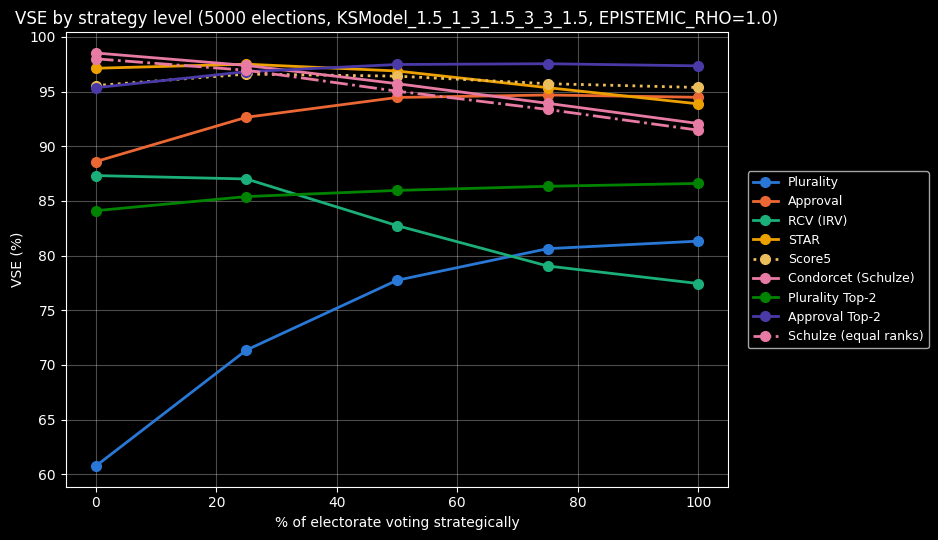

```python
STRATEGY_AXIS = {
    "100% honest": 0,
    "25% strategic": 25,
    "50% strategic": 50,
    "75% strategic": 75,
    "100% strategic": 100,
}

fig, ax = plt.subplots(figsize=(9.5, 5.5))
for label, _ in PRE_NOISE_METHODS:
    points = sorted(
        (STRATEGY_AXIS[chooser_label], mean_)
        for chooser_label, mean_, _ in rows_by_method[label]
        if chooser_label in STRATEGY_AXIS
    )
    if not points:
        continue
    xs, ys = zip(*points)
    ax.plot(xs, [y * 100 for y in ys], marker="o", markersize=7, linewidth=2,
            color=METHOD_COLORS[label], linestyle=METHOD_LINESTYLES[label], label=label)

ax.set_xlabel("% of electorate voting strategically")
ax.set_ylabel("VSE (%)")
ax.set_title(f"VSE by strategy level ({NITER} elections, {MODEL}, EPISTEMIC_RHO={EPISTEMIC_RHO})")
ax.legend(fontsize=9, loc="center left", bbox_to_anchor=(1.02, 0.5))
ax.grid(True, alpha=0.3)
plt.tight_layout()
plt.show()
```

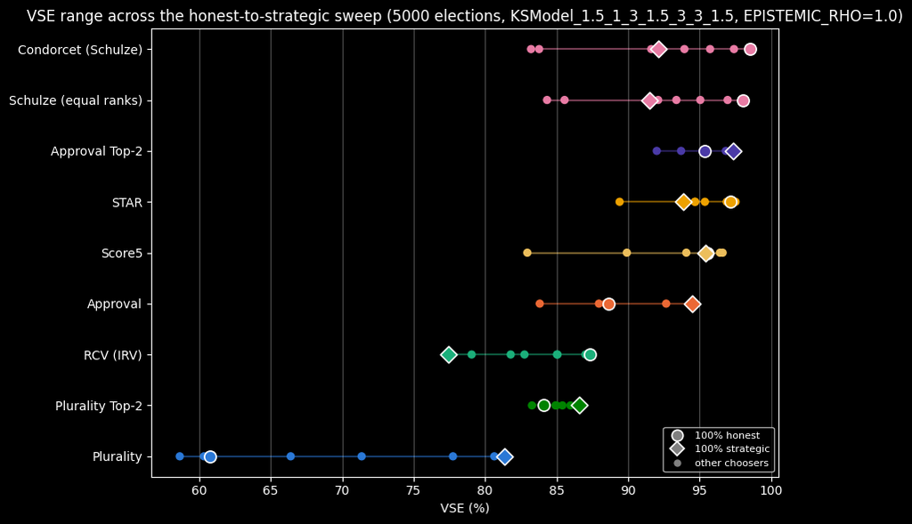

```python
# sort methods by their max VSE across any chooser, so the worst method is at the bottom of the y-axis and the best method is at the top.
_sorted_labels = sorted(
    (label for label, _ in PRE_NOISE_METHODS if rows_by_method[label]),
    key=lambda label: max(mean_ for _, mean_, _ in rows_by_method[label])
)

fig, ax = plt.subplots(figsize=(9, 6))
# _sorted_labels is ascending by max VSE across any chooser; plotting in that order puts the
# worst method at row 0 (the bottom of a matplotlib y-axis) and the best method at the top row,
# as intended.
for row_i, label in enumerate(_sorted_labels):
    vses = [mean_ * 100 for _, mean_, _ in rows_by_method[label]]
    color = METHOD_COLORS[label]
    ax.plot([min(vses), max(vses)], [row_i, row_i], color=color, linewidth=1.5, alpha=0.5, zorder=1)
    for chooser_label, mean_, _ in rows_by_method[label]:
        is_honest = chooser_label == "100% honest"
        is_strategic = chooser_label == "100% strategic"
        ax.scatter(mean_ * 100, row_i,
                   marker="D" if is_strategic else "o",
                   s=90 if (is_honest or is_strategic) else 45,
                   color=color,
                   edgecolors=FG_COLOR if (is_honest or is_strategic) else "none",
                   linewidths=1.2 if (is_honest or is_strategic) else 0,
                   zorder=3 if (is_honest or is_strategic) else 2)

ax.set_yticks(range(len(_sorted_labels)))
ax.set_yticklabels(_sorted_labels)
ax.set_xlabel("VSE (%)")
ax.set_title(f"VSE range across the honest-to-strategic sweep ({NITER} elections, "
             f"{MODEL}, EPISTEMIC_RHO={EPISTEMIC_RHO})")
_marker_legend = [
    Line2D([0], [0], marker="o", linestyle="none", markersize=9,
           markerfacecolor="gray", markeredgecolor=FG_COLOR, markeredgewidth=1.2, label="100% honest"),
    Line2D([0], [0], marker="D", linestyle="none", markersize=8,
           markerfacecolor="gray", markeredgecolor=FG_COLOR, markeredgewidth=1.2, label="100% strategic"),
    Line2D([0], [0], marker="o", linestyle="none", markersize=6,
           markerfacecolor="gray", markeredgecolor="none", label="other choosers"),
]
ax.legend(handles=_marker_legend, fontsize=8, loc="lower right")
ax.grid(True, axis="x", alpha=0.3)
plt.tight_layout()
plt.show()
```

## 13. Sweeping all three degradation parameters: VSE vs. voter information

The reusable sweep tooling defined below (`sweep_methods`, `comparison_table`, `comparison_chart`) is also what Section 14 and later sections use for smaller, focused comparisons.

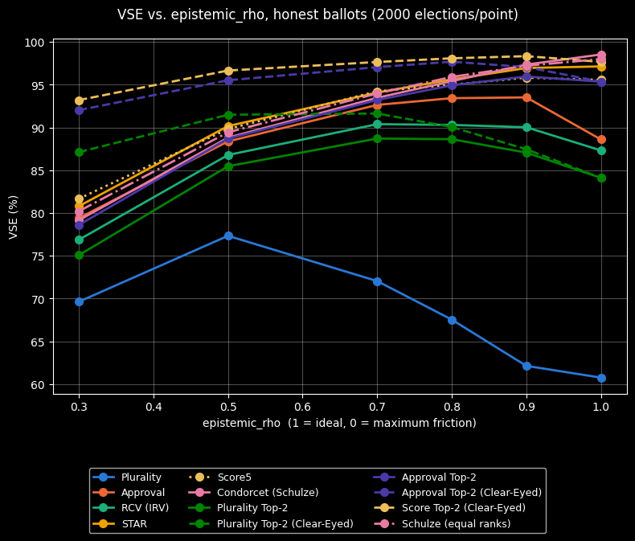

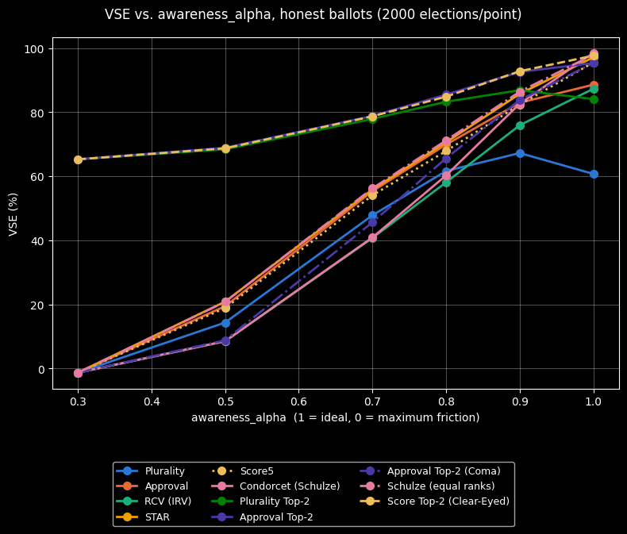

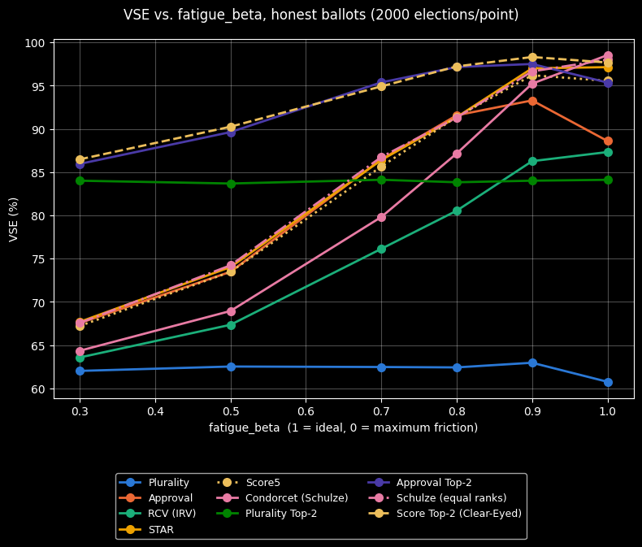

```python
for sweep_param, param_methods in SWEEP_PARAMS:
    _by_value = R.sweep_results_by_param[sweep_param]
    _values = sorted(_by_value)
    fig, ax_hon = plt.subplots(figsize=(8, 5.5))
    for label, _ in param_methods:
        color = METHOD_COLORS[label]
        style = METHOD_LINESTYLES[label]
        hon_vses = [_by_value[v][(label, "honBallot")][0] * 100 for v in _values]
        ax_hon.plot(_values, hon_vses, marker="o", markersize=7, linewidth=2, color=color, linestyle=style, label=label)
    ax_hon.set_xlabel(f"{sweep_param}  (1 = ideal, 0 = maximum friction)")
    ax_hon.grid(True, alpha=0.3)
    ax_hon.set_ylabel("VSE (%)")
    handles, labels_ = ax_hon.get_legend_handles_labels()
    fig.legend(handles, labels_, loc="lower center", fontsize=9, ncol=3, bbox_to_anchor=(0.5, -0.22))
    fig.suptitle(f"VSE vs. {sweep_param}, honest ballots ({SWEEP_NITER} elections/point)")
    plt.tight_layout()
    plt.show()
```

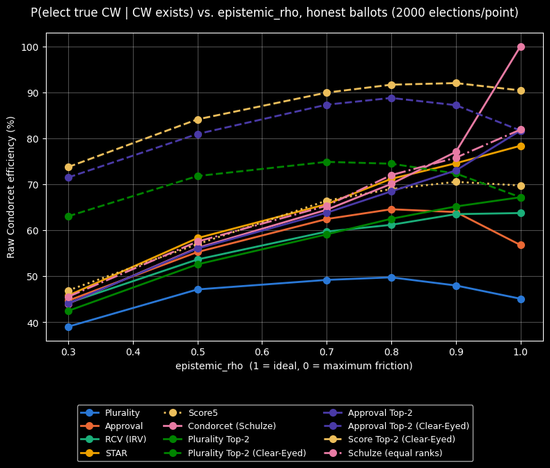

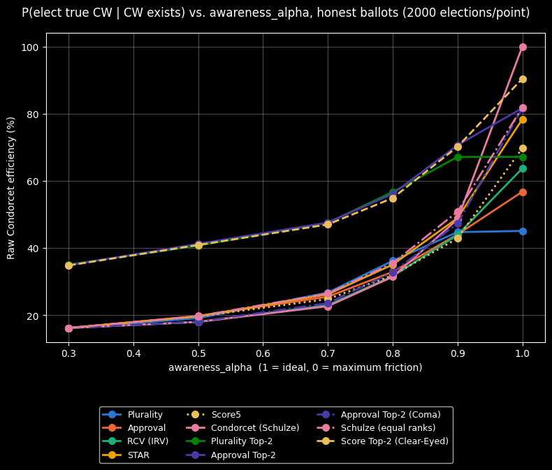

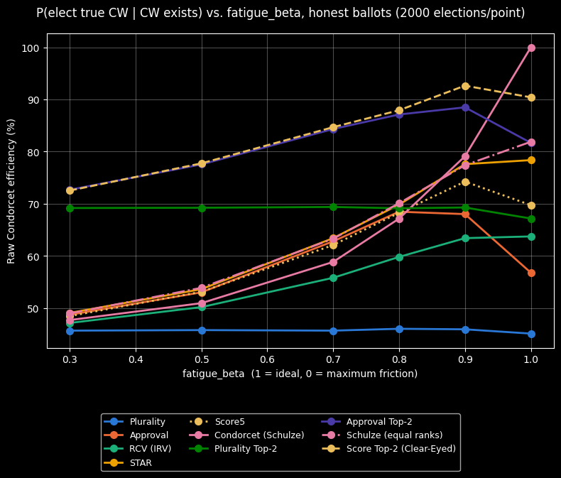

```python
for sweep_param, param_methods in SWEEP_PARAMS:
    _ce_by_value = R.sweep_ce_by_param[sweep_param]
    _values = sorted(_ce_by_value)
    fig, ax_hon = plt.subplots(figsize=(8, 5.5))
    for label, _ in param_methods:
        color = METHOD_COLORS[label]
        style = METHOD_LINESTYLES[label]
        hon_ces = [_ce_by_value[v].get((label, "honBallot"), float("nan")) * 100 for v in _values]
        ax_hon.plot(_values, hon_ces, marker="o", markersize=7, linewidth=2, color=color, linestyle=style, label=label)
    ax_hon.set_xlabel(f"{sweep_param}  (1 = ideal, 0 = maximum friction)")
    ax_hon.grid(True, alpha=0.3)
    ax_hon.set_ylabel("Raw Condorcet efficiency (%)")
    handles, labels_ = ax_hon.get_legend_handles_labels()
    fig.legend(handles, labels_, loc="lower center", fontsize=9, ncol=3, bbox_to_anchor=(0.5, -0.22))
    fig.suptitle(f"P(elect true CW | CW exists) vs. {sweep_param}, honest ballots ({SWEEP_NITER} elections/point)")
    plt.tight_layout()
    plt.show()
```

## 14. Approval's flavors vs. STAR/Schulze, across noise and both friction mechanisms

The motivating question: Approval Top-2 (a coarse 0/1 ballot, decided over two rounds) is the flavor of Approval actually being adopted (e.g. St. Louis). STAR and Schulze both let voters express far more information in a single round. Does STAR/Schulze's honest-VSE edge over Approval hold up once that richer signal degrades -- and does Approval Top-2's *delayed, two-candidate* runoff let voters recover some of that edge, on the theory that deciding between just two finalists is easy to get right even if the crowded primary wasn't?

```python
# No new simulation here -- Section 13 already swept every method (epistemic_rho) or every
# PRE_NOISE_METHODS method (awareness_alpha/fatigue_beta) across all three parameters; this just
# filters those already-computed R.results down to COMPARE_LABELS (defined in Section 9, above --
# hoisted there so Section 9's own baseline run can build its paired-comparison lists from it
# too). "Approval Top-2 (clear-eyed runoff)" is simply absent from the awareness_alpha/fatigue_beta
# dicts (Section 13 never simulated it there), not filtered out here -- see Section 13's markdown
# for why. "Score5" is included so it rides along as a no-runoff reference line on every chart
# below; Section 22 reuses this same compare_by_param (and the R.joint_results built from
# COMPARE_LABELS further down) instead of running its own separate STAR-vs-Score5 simulation.
compare_by_param = {
    param: {value: {k: v for k, v in by_value.items() if k[0] in COMPARE_LABELS}
            for value, by_value in R.sweep_results_by_param[param].items()}
    for param, _ in SWEEP_PARAMS
}
compare_ce_by_param = {
    param: {value: {k: v for k, v in by_value.items() if k[0] in COMPARE_LABELS}
            for value, by_value in R.sweep_ce_by_param[param].items()}
    for param, _ in SWEEP_PARAMS
}
```

Epistemic noise (EPISTEMIC_RHO)

| Method | epistemic_rho=0.30 | epistemic_rho=0.50 | epistemic_rho=0.70 | epistemic_rho=0.80 | epistemic_rho=0.90 | epistemic_rho=1.00 |
| --- | --- | --- | --- | --- | --- | --- |
| Plurality | 69.6% (+/-2.1) | 77.3% (+/-1.9) | 72.0% (+/-2.6) | 67.5% (+/-2.8) | 62.1% (+/-3.2) | 60.8% (+/-1.8) |
| Plurality Top-2 | 75.1% (+/-1.7) | 85.5% (+/-1.2) | 88.7% (+/-1.1) | 88.6% (+/-1.2) | 87.1% (+/-1.4) | 84.1% (+/-1.1) |
| Plurality Top-2 (Clear-Eyed) | 87.1% (+/-1.1) | 91.5% (+/-1.0) | 91.6% (+/-1.0) | 90.1% (+/-1.2) | 87.5% (+/-1.5) | 84.1% (+/-1.1) |
| RCV (IRV) | 76.9% (+/-1.6) | 86.8% (+/-1.1) | 90.4% (+/-0.9) | 90.3% (+/-1.0) | 90.0% (+/-1.1) | 87.3% (+/-0.8) |
| Approval | 79.4% (+/-1.4) | 88.4% (+/-0.9) | 92.6% (+/-0.6) | 93.4% (+/-0.6) | 93.5% (+/-0.6) | 88.6% (+/-0.6) |
| Approval Top-2 | 78.6% (+/-1.5) | 88.7% (+/-0.9) | 93.2% (+/-0.6) | 94.9% (+/-0.5) | 96.0% (+/-0.5) | 95.4% (+/-0.4) |
| Approval Top-2 (Clear-Eyed) | 92.0% (+/-0.8) | 95.5% (+/-0.6) | 97.1% (+/-0.4) | 97.7% (+/-0.4) | 97.1% (+/-0.4) | 95.4% (+/-0.4) |
| STAR | 80.8% (+/-1.4) | 90.2% (+/-0.8) | 94.1% (+/-0.6) | 95.6% (+/-0.5) | 97.0% (+/-0.4) | 97.1% (+/-0.3) |
| Score5 | 81.7% (+/-1.3) | 89.8% (+/-0.9) | 94.2% (+/-0.6) | 95.0% (+/-0.5) | 95.8% (+/-0.4) | 95.6% (+/-0.3) |
| Score Top-2 (Clear-Eyed) | 93.2% (+/-0.7) | 96.7% (+/-0.5) | 97.7% (+/-0.4) | 98.1% (+/-0.3) | 98.3% (+/-0.3) | 97.7% (+/-0.3) |
| Condorcet (Schulze) | 79.2% (+/-1.5) | 88.8% (+/-0.9) | 93.5% (+/-0.6) | 95.4% (+/-0.5) | 97.4% (+/-0.3) | 98.5% (+/-0.2) |
| Schulze (equal ranks) | 80.2% (+/-1.4) | 89.4% (+/-0.9) | 94.0% (+/-0.6) | 95.9% (+/-0.5) | 97.2% (+/-0.3) | 98.0% (+/-0.2) |

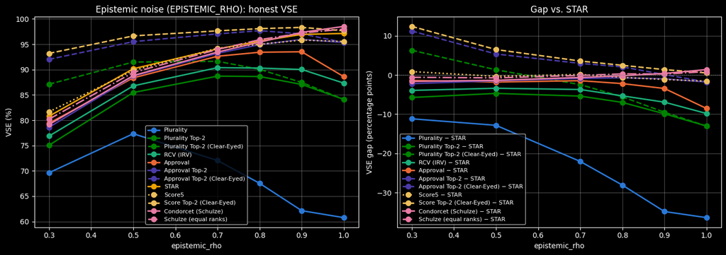

Unfamiliarity (AWARENESS_ALPHA)

| Method | awareness_alpha=0.30 | awareness_alpha=0.50 | awareness_alpha=0.70 | awareness_alpha=0.80 | awareness_alpha=0.90 | awareness_alpha=1.00 |
| --- | --- | --- | --- | --- | --- | --- |
| Plurality | -1.3% (+/-4.7) | 14.3% (+/-4.2) | 47.8% (+/-3.0) | 61.7% (+/-2.6) | 67.3% (+/-2.6) | 60.8% (+/-1.8) |
| Plurality Top-2 | 65.3% (+/-2.1) | 68.4% (+/-2.0) | 77.9% (+/-1.6) | 83.3% (+/-1.4) | 86.9% (+/-1.4) | 84.1% (+/-1.1) |
| RCV (IRV) | -1.3% (+/-4.7) | 8.5% (+/-4.4) | 40.7% (+/-3.2) | 58.1% (+/-2.6) | 75.9% (+/-1.9) | 87.3% (+/-0.8) |
| Approval | -1.3% (+/-4.7) | 19.4% (+/-4.0) | 55.3% (+/-2.4) | 69.9% (+/-1.7) | 83.0% (+/-1.1) | 88.6% (+/-0.6) |
| Approval Top-2 (Coma) | -1.3% (+/-4.7) | 8.8% (+/-4.4) | 45.6% (+/-2.9) | 65.6% (+/-2.0) | 83.8% (+/-1.2) | 95.4% (+/-0.4) |
| Approval Top-2 | 65.3% (+/-2.1) | 68.9% (+/-2.0) | 78.8% (+/-1.5) | 85.5% (+/-1.1) | 92.6% (+/-0.7) | 95.4% (+/-0.4) |
| STAR | -1.3% (+/-4.7) | 20.9% (+/-3.9) | 55.9% (+/-2.4) | 70.6% (+/-1.7) | 85.7% (+/-1.0) | 97.1% (+/-0.3) |
| Score5 | -1.3% (+/-4.7) | 18.9% (+/-4.0) | 54.1% (+/-2.4) | 67.9% (+/-1.8) | 82.4% (+/-1.1) | 95.6% (+/-0.3) |
| Score Top-2 (Clear-Eyed) | 65.3% (+/-2.1) | 68.7% (+/-2.0) | 78.7% (+/-1.5) | 84.9% (+/-1.2) | 92.8% (+/-0.7) | 97.7% (+/-0.3) |
| Condorcet (Schulze) | -1.3% (+/-4.7) | 8.5% (+/-4.4) | 40.9% (+/-3.2) | 60.3% (+/-2.4) | 82.6% (+/-1.4) | 98.5% (+/-0.2) |
| Schulze (equal ranks) | -1.3% (+/-4.7) | 20.8% (+/-3.9) | 56.2% (+/-2.4) | 71.2% (+/-1.7) | 86.4% (+/-1.0) | 98.0% (+/-0.2) |

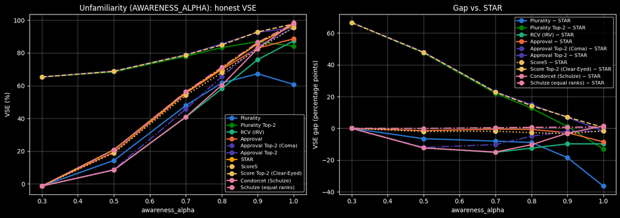

Ballot fatigue (FATIGUE_BETA)

| Method | fatigue_beta=0.30 | fatigue_beta=0.50 | fatigue_beta=0.70 | fatigue_beta=0.80 | fatigue_beta=0.90 | fatigue_beta=1.00 |
| --- | --- | --- | --- | --- | --- | --- |
| Plurality | 62.0% (+/-2.9) | 62.5% (+/-2.9) | 62.5% (+/-2.9) | 62.4% (+/-2.9) | 63.0% (+/-2.9) | 60.8% (+/-1.8) |
| Plurality Top-2 | 84.0% (+/-1.8) | 83.7% (+/-1.9) | 84.1% (+/-1.8) | 83.8% (+/-1.8) | 84.0% (+/-1.8) | 84.1% (+/-1.1) |
| RCV (IRV) | 63.6% (+/-2.9) | 67.3% (+/-2.7) | 76.1% (+/-2.3) | 80.5% (+/-1.9) | 86.3% (+/-1.5) | 87.3% (+/-0.8) |
| Approval | 67.5% (+/-2.7) | 73.5% (+/-2.4) | 86.5% (+/-1.5) | 91.6% (+/-1.1) | 93.3% (+/-0.7) | 88.6% (+/-0.6) |
| Approval Top-2 | 86.0% (+/-1.7) | 89.6% (+/-1.5) | 95.4% (+/-0.8) | 97.2% (+/-0.5) | 97.5% (+/-0.4) | 95.4% (+/-0.4) |
| STAR | 67.7% (+/-2.7) | 74.0% (+/-2.4) | 86.4% (+/-1.5) | 91.4% (+/-1.1) | 97.0% (+/-0.4) | 97.1% (+/-0.3) |
| Score5 | 67.2% (+/-2.7) | 73.5% (+/-2.4) | 85.6% (+/-1.6) | 91.4% (+/-1.1) | 96.2% (+/-0.5) | 95.6% (+/-0.3) |
| Score Top-2 (Clear-Eyed) | 86.5% (+/-1.7) | 90.3% (+/-1.4) | 94.9% (+/-0.9) | 97.2% (+/-0.5) | 98.3% (+/-0.3) | 97.7% (+/-0.3) |
| Condorcet (Schulze) | 64.3% (+/-2.8) | 68.9% (+/-2.6) | 79.8% (+/-2.0) | 87.2% (+/-1.5) | 95.2% (+/-0.7) | 98.5% (+/-0.2) |
| Schulze (equal ranks) | 67.6% (+/-2.7) | 74.2% (+/-2.4) | 86.7% (+/-1.5) | 91.3% (+/-1.1) | 96.7% (+/-0.5) | 98.0% (+/-0.2) |

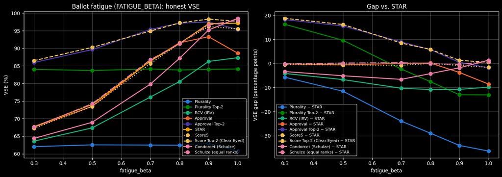

```python
for sweep_param, param_title in [
    ("epistemic_rho", "Epistemic noise (EPISTEMIC_RHO)"),
    ("awareness_alpha", "Unfamiliarity (AWARENESS_ALPHA)"),
    ("fatigue_beta", "Ballot fatigue (FATIGUE_BETA)"),
]:
    display(Markdown(f"#### {param_title}"))
    # Derived from what's actually present rather than a hardcoded exclusion: "Approval Top-2
    # (Clear-Eyed)" is only in compare_by_param["epistemic_rho"] (see the cell above), so it
    # naturally drops out of the other two params' tables/charts here without special-casing.
    _some_value = next(iter(compare_by_param[sweep_param]))
    _present_labels = {k[0] for k in compare_by_param[sweep_param][_some_value]}
    _compare_labels_here = [l for l in COMPARE_LABELS if l in _present_labels]
    comparison_table(compare_by_param[sweep_param], _compare_labels_here, sweep_param)
    comparison_chart(compare_by_param[sweep_param], _compare_labels_here, sweep_param,
                      baseline_label="STAR", title=f"{param_title}: honest VSE")
```

Epistemic noise (EPISTEMIC_RHO) (baseline: Approval Top-2)

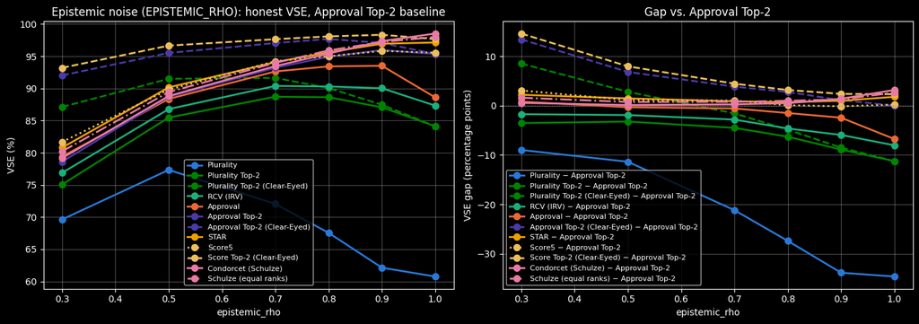

Unfamiliarity (AWARENESS_ALPHA) (baseline: Approval Top-2)

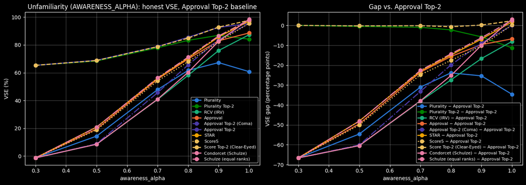

Ballot fatigue (FATIGUE_BETA) (baseline: Approval Top-2)

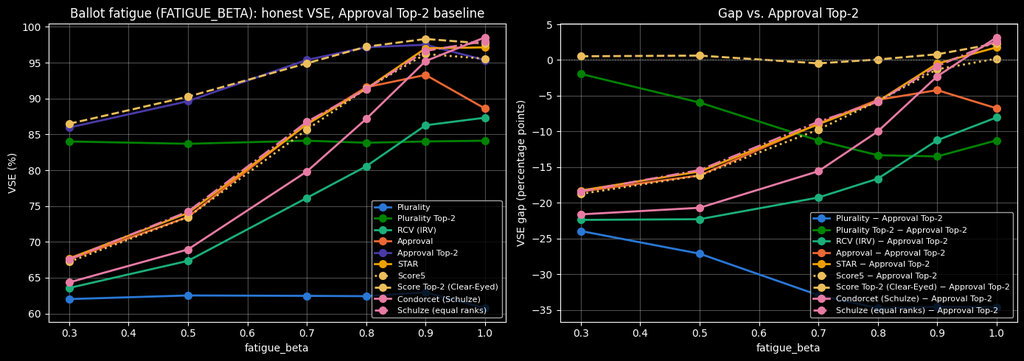

```python
for sweep_param, param_title in [
    ("epistemic_rho", "Epistemic noise (EPISTEMIC_RHO)"),
    ("awareness_alpha", "Unfamiliarity (AWARENESS_ALPHA)"),
    ("fatigue_beta", "Ballot fatigue (FATIGUE_BETA)"),
]:
    display(Markdown(f"#### {param_title} (baseline: Approval Top-2)"))
    _some_value = next(iter(compare_by_param[sweep_param]))
    _present_labels = {k[0] for k in compare_by_param[sweep_param][_some_value]}
    _compare_labels_here = [l for l in COMPARE_LABELS if l in _present_labels]
    comparison_chart(compare_by_param[sweep_param], _compare_labels_here, sweep_param,
                      baseline_label="Approval Top-2",
                      title=f"{param_title}: honest VSE, Approval Top-2 baseline")
```

## 15. Condorcet Efficiency Under Sweeps

Epistemic noise (EPISTEMIC_RHO): raw Condorcet efficiency

| Method | epistemic_rho=0.30 | epistemic_rho=0.50 | epistemic_rho=0.70 | epistemic_rho=0.80 | epistemic_rho=0.90 | epistemic_rho=1.00 |
| --- | --- | --- | --- | --- | --- | --- |
| Plurality | 39.0% | 47.1% | 49.2% | 49.7% | 48.0% | 45.1% |
| Plurality Top-2 | 42.5% | 52.6% | 59.1% | 62.5% | 65.2% | 67.2% |
| Plurality Top-2 (Clear-Eyed) | 63.0% | 71.8% | 74.9% | 74.5% | 72.3% | 67.2% |
| RCV (IRV) | 44.2% | 53.6% | 59.7% | 61.2% | 63.5% | 63.7% |
| Approval | 44.7% | 55.3% | 62.4% | 64.6% | 64.0% | 56.8% |
| Approval Top-2 | 44.1% | 56.0% | 63.8% | 68.5% | 73.0% | 81.7% |
| Approval Top-2 (Clear-Eyed) | 71.5% | 80.9% | 87.3% | 88.8% | 87.2% | 81.7% |
| STAR | 45.8% | 58.3% | 65.7% | 71.2% | 74.6% | 78.4% |
| Score5 | 46.9% | 57.0% | 66.4% | 69.0% | 70.5% | 69.7% |
| Score Top-2 (Clear-Eyed) | 73.8% | 84.1% | 89.9% | 91.7% | 92.0% | 90.4% |
| Condorcet (Schulze) | 44.0% | 56.2% | 64.5% | 70.1% | 77.0% | 100.0% |
| Schulze (equal ranks) | 45.6% | 57.5% | 65.3% | 72.0% | 75.8% | 81.9% |

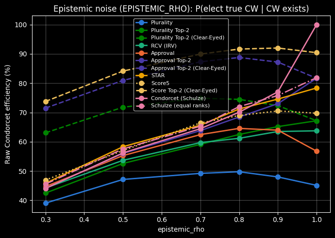

Unfamiliarity (AWARENESS_ALPHA): raw Condorcet efficiency

| Method | awareness_alpha=0.30 | awareness_alpha=0.50 | awareness_alpha=0.70 | awareness_alpha=0.80 | awareness_alpha=0.90 | awareness_alpha=1.00 |
| --- | --- | --- | --- | --- | --- | --- |
| Plurality | 16.2% | 19.1% | 26.7% | 36.2% | 44.8% | 45.1% |
| Plurality Top-2 | 35.1% | 40.8% | 47.5% | 56.7% | 67.1% | 67.2% |
| RCV (IRV) | 16.2% | 18.0% | 23.0% | 31.6% | 43.9% | 63.7% |
| Approval | 16.2% | 19.8% | 25.5% | 32.9% | 44.1% | 56.8% |
| Approval Top-2 (Coma) | 16.2% | 18.1% | 23.6% | 32.8% | 47.3% | 81.7% |
| Approval Top-2 | 34.9% | 41.3% | 47.6% | 56.2% | 70.6% | 81.7% |
| STAR | 16.2% | 19.7% | 26.2% | 35.1% | 48.9% | 78.4% |
| Score5 | 16.2% | 19.6% | 24.8% | 31.9% | 42.9% | 69.7% |
| Score Top-2 (Clear-Eyed) | 34.8% | 40.9% | 47.0% | 54.9% | 70.2% | 90.4% |
| Condorcet (Schulze) | 16.2% | 18.0% | 22.7% | 31.4% | 48.6% | 100.0% |
| Schulze (equal ranks) | 16.2% | 19.7% | 26.5% | 35.5% | 50.8% | 81.9% |

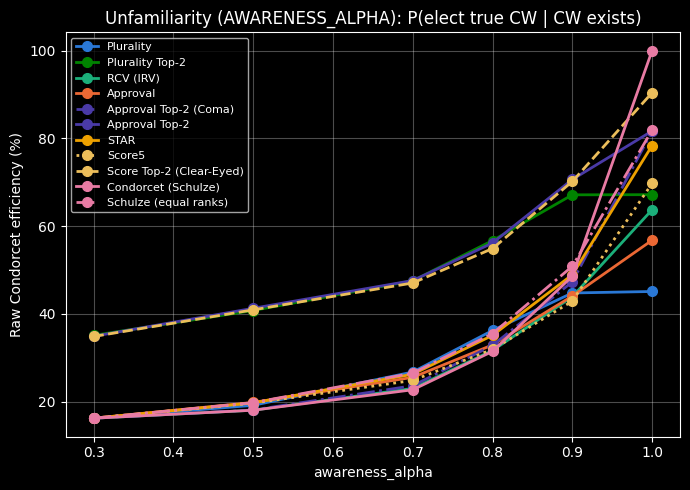

Ballot fatigue (FATIGUE_BETA): raw Condorcet efficiency

| Method | fatigue_beta=0.30 | fatigue_beta=0.50 | fatigue_beta=0.70 | fatigue_beta=0.80 | fatigue_beta=0.90 | fatigue_beta=1.00 |
| --- | --- | --- | --- | --- | --- | --- |
| Plurality | 45.7% | 45.8% | 45.7% | 46.0% | 45.9% | 45.1% |
| Plurality Top-2 | 69.2% | 69.2% | 69.4% | 69.1% | 69.3% | 67.2% |
| RCV (IRV) | 47.1% | 50.2% | 55.8% | 59.8% | 63.4% | 63.7% |
| Approval | 48.7% | 53.0% | 62.8% | 68.5% | 68.0% | 56.8% |
| Approval Top-2 | 72.7% | 77.5% | 84.3% | 87.1% | 88.5% | 81.7% |
| STAR | 49.1% | 53.6% | 63.4% | 69.8% | 77.6% | 78.4% |
| Score5 | 48.5% | 53.1% | 62.1% | 68.3% | 74.3% | 69.7% |
| Score Top-2 (Clear-Eyed) | 72.5% | 77.7% | 84.7% | 87.9% | 92.7% | 90.4% |
| Condorcet (Schulze) | 47.7% | 50.9% | 58.8% | 67.2% | 79.1% | 100.0% |
| Schulze (equal ranks) | 49.0% | 53.9% | 63.3% | 70.1% | 77.4% | 81.9% |

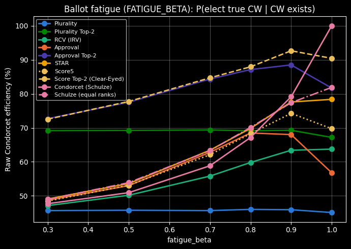

```python
for sweep_param, param_title in [
    ("epistemic_rho", "Epistemic noise (EPISTEMIC_RHO)"),
    ("awareness_alpha", "Unfamiliarity (AWARENESS_ALPHA)"),
    ("fatigue_beta", "Ballot fatigue (FATIGUE_BETA)"),
]:
    display(Markdown(f"#### {param_title}: raw Condorcet efficiency"))
    _some_value = next(iter(compare_ce_by_param[sweep_param]))
    _present_labels = {k[0] for k in compare_ce_by_param[sweep_param][_some_value]}
    _compare_labels_here = [l for l in COMPARE_LABELS if l in _present_labels]
    ce_by_value = compare_ce_by_param[sweep_param]
    values = sorted(ce_by_value)
    header = ["Method"] + [f"{sweep_param}={v:.2f}" for v in values]
    lines = ["| " + " | ".join(header) + " |", "|" + "---|" * len(header)]
    for label in _compare_labels_here:
        row = [label]
        for v in values:
            ce = ce_by_value[v].get((label, "honBallot"))
            row.append("n/a" if ce is None or ce != ce else f"{ce * 100:.1f}%")
        lines.append("| " + " | ".join(row) + " |")
    display(Markdown("\n".join(lines)))

    fig, ax = plt.subplots(figsize=(7, 5))
    for label in _compare_labels_here:
        ces = [ce_by_value[v].get((label, "honBallot"), float("nan")) * 100 for v in values]
        ax.plot(values, ces, marker="o", markersize=7, linewidth=2,
                color=METHOD_COLORS.get(label), linestyle=METHOD_LINESTYLES.get(label, "-"), label=label)
    ax.set_xlabel(sweep_param)
    ax.set_ylabel("Raw Condorcet efficiency (%)")
    ax.set_title(f"{param_title}: P(elect true CW | CW exists)")
    ax.legend(fontsize=8)
    ax.grid(True, alpha=0.3)
    plt.tight_layout()
    plt.show()
```

```python
# Plain-language readout: does each Approval flavor's gap to STAR shrink, hold, or reverse?
_narrowing_lines = [
    "| Method | Parameter | STAR VSE - method VSE (ideal) | STAR VSE - method VSE (min value) | STAR-lead change (pp) | Direction |",
    "|---|---|---|---|---|---|",
]

_target_methods = ["Approval", "Approval Top-2", "Approval Top-2 (Clear-Eyed)"]
_sweeps = [
    ("epistemic_rho", "Epistemic noise"),
    ("awareness_alpha", "Unfamiliarity"),
    ("fatigue_beta", "Ballot fatigue"),
]

for label in _target_methods:  # group by method first
    for sweep_param, param_title in _sweeps:
        results_by_value = compare_by_param[sweep_param]
        _values = sorted(results_by_value)
        _ideal_v = max(_values)
        _max_friction_v = min(_values)

        _ideal_results = results_by_value[_ideal_v]
        _max_results = results_by_value[_max_friction_v]

        if ("STAR", "honBallot") not in _ideal_results or (label, "honBallot") not in _ideal_results:
            continue

        star_ideal = _ideal_results[("STAR", "honBallot")][0] * 100
        meth_ideal = _ideal_results[(label, "honBallot")][0] * 100
        star_max = _max_results[("STAR", "honBallot")][0] * 100
        meth_max = _max_results[(label, "honBallot")][0] * 100

        lead_ideal = star_ideal - meth_ideal
        lead_max = star_max - meth_max
        lead_delta = lead_max - lead_ideal

        if lead_max < lead_ideal:
            direction = "narrowed"
        elif lead_max > lead_ideal:
            direction = "widened"
        else:
            direction = "unchanged"

        if (lead_ideal > 0 and lead_max < 0) or (lead_ideal < 0 and lead_max > 0):
            direction += " (reversed sign)"

        ideal_cell = f"{star_ideal:.1f}-{meth_ideal:.1f}<br>[{lead_ideal:+.1f} pp]"
        max_cell = f"{star_max:.1f}-{meth_max:.1f}<br>[{lead_max:+.1f} pp]"

        _narrowing_lines.append(
            f"| {label} | {param_title} | {ideal_cell} | {max_cell} | "
            f"{lead_ideal:+.1f} → {lead_max:+.1f} ({lead_delta:+.1f}) | {direction} |"
        )
display(Markdown("\n".join(_narrowing_lines)))
```

| Method | Parameter | STAR VSE - method VSE (ideal) | STAR VSE - method VSE (min value) | STAR-lead change (pp) | Direction |
| --- | --- | --- | --- | --- | --- |
| Approval | Epistemic noise | 97.1-88.6 [+8.5 pp] | 80.8-79.4 [+1.4 pp] | +8.5 → +1.4 (-7.2) | narrowed |
| Approval | Unfamiliarity | 97.1-88.6 [+8.5 pp] | -1.3--1.3 [+0.0 pp] | +8.5 → +0.0 (-8.5) | narrowed |
| Approval | Ballot fatigue | 97.1-88.6 [+8.5 pp] | 67.7-67.5 [+0.1 pp] | +8.5 → +0.1 (-8.4) | narrowed |
| Approval Top-2 | Epistemic noise | 97.1-95.4 [+1.8 pp] | 80.8-78.6 [+2.2 pp] | +1.8 → +2.2 (+0.4) | widened |
| Approval Top-2 | Unfamiliarity | 97.1-95.4 [+1.8 pp] | -1.3-65.3 [-66.6 pp] | +1.8 → -66.6 (-68.4) | narrowed (reversed sign) |
| Approval Top-2 | Ballot fatigue | 97.1-95.4 [+1.8 pp] | 67.7-86.0 [-18.3 pp] | +1.8 → -18.3 (-20.0) | narrowed (reversed sign) |
| Approval Top-2 (Clear-Eyed) | Epistemic noise | 97.1-95.4 [+1.8 pp] | 80.8-92.0 [-11.2 pp] | +1.8 → -11.2 (-13.0) | narrowed (reversed sign) |

## 16. Joint "realistic conditions": all three degradation parameters at once

Every sweep above holds two of `EPISTEMIC_RHO`/`AWARENESS_ALPHA`/`FATIGUE_BETA` at their ideal value (`1.0`) while moving the third. That isolates each mechanism cleanly, but no real election holds two of the three perfectly -- voters are simultaneously somewhat uncertain about their own preferences, somewhat unfamiliar with minor candidates, and somewhat prone to not finishing a long ballot. STAR and Schulze's honest-VSE edge over Approval's flavors was built entirely on the assumption that all three hold at once (Section 8's main run: `EPISTEMIC_RHO=AWARENESS_ALPHA=FATIGUE_BETA=1.0`). This section asks what's left of that edge once none of the three ideal assumptions hold simultaneously, and puts a number on it rather than reading it off three separate charts.

Four fixed scenarios (not swept, all three parameters move together), same `COMPARE_LABELS` as above, honest ballots only:

| Method | Ideal | Mild friction | Moderate friction | Heavy friction |
| --- | --- | --- | --- | --- |
| Plurality | 60.8% (+/-1.8) | 70.8% (+/-1.5) | 61.6% (+/-1.4) | 41.6% (+/-1.7) |
| Plurality Top-2 | 84.1% (+/-1.1) | 88.2% (+/-0.7) | 82.3% (+/-0.8) | 72.5% (+/-1.0) |
| Plurality Top-2 (Clear-Eyed) | 84.1% (+/-1.1) | 88.7% (+/-0.7) | 83.4% (+/-0.8) | 74.3% (+/-1.0) |
| RCV (IRV) | 87.3% (+/-0.8) | 75.2% (+/-1.1) | 51.2% (+/-1.6) | 28.8% (+/-2.0) |
| Approval | 88.6% (+/-0.6) | 83.1% (+/-0.7) | 64.5% (+/-1.2) | 43.2% (+/-1.7) |
| Approval Top-2 (Coma) | 95.4% (+/-0.4) | 81.6% (+/-0.8) | 56.6% (+/-1.4) | 31.6% (+/-1.9) |
| Approval Top-2 | 95.4% (+/-0.4) | 92.1% (+/-0.4) | 82.8% (+/-0.8) | 73.0% (+/-1.0) |
| Approval Top-2 (Clear-Eyed) | 95.4% (+/-0.4) | 92.8% (+/-0.4) | 84.0% (+/-0.8) | 74.8% (+/-1.0) |
| STAR | 97.1% (+/-0.3) | 83.9% (+/-0.7) | 64.8% (+/-1.2) | 43.7% (+/-1.7) |
| Score5 | 95.6% (+/-0.3) | 82.5% (+/-0.7) | 64.2% (+/-1.2) | 42.5% (+/-1.7) |
| Score Top-2 (Clear-Eyed) | 97.7% (+/-0.3) | 92.8% (+/-0.4) | 84.2% (+/-0.7) | 75.1% (+/-1.0) |
| Condorcet (Schulze) | 98.5% (+/-0.2) | 76.4% (+/-1.0) | 49.8% (+/-1.7) | 28.4% (+/-2.1) |
| Schulze (equal ranks) | 98.0% (+/-0.2) | 84.2% (+/-0.7) | 65.1% (+/-1.2) | 44.1% (+/-1.7) |

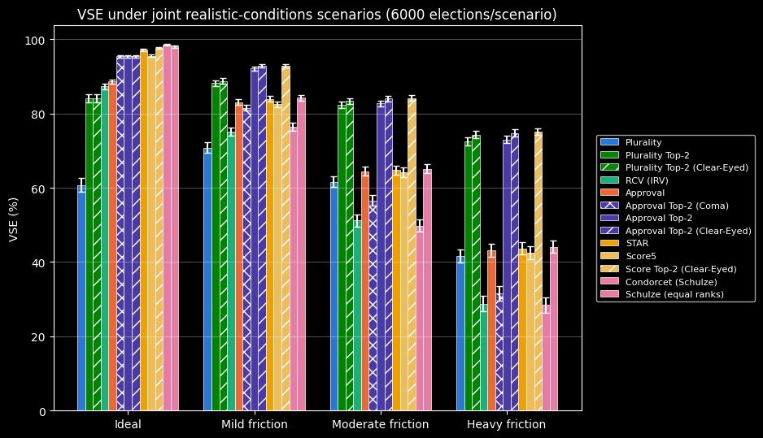

```python
def scenario_table_and_plot(method_labels):
    # Table: rows = method, columns = scenario, cell = VSE% (+/-CI)
    _joint_table_lines = ["| Method | " + " | ".join(_scenario_names) + " |",
                        "|---|" + "---|" * len(_scenario_names)]
    for label in method_labels:
        row = [label]
        for name in _scenario_names:
            mean_, ci = R.joint_results[name][(label, "honBallot")]
            row.append(f"{mean_ * 100:.1f}% (+/-{ci * 100:.1f})")
        _joint_table_lines.append("| " + " | ".join(row) + " |")
    display(Markdown("\n".join(_joint_table_lines)))

    # Grouped bar chart: one group per scenario, one bar per method.
    fig, ax = plt.subplots(figsize=(9.5, 5.5))
    _n_labels = len(method_labels)
    _bar_width = 0.8 / _n_labels
    _x = np.arange(len(_scenario_names))
    for i, label in enumerate(method_labels):
        vses = [R.joint_results[name][(label, "honBallot")][0] * 100 for name in _scenario_names]
        cis = [R.joint_results[name][(label, "honBallot")][1] * 100 for name in _scenario_names]
        hatch = "//" if "Clear-Eyed" in label else ("xx" if "Coma" in label else None)
        ax.bar(_x + i * _bar_width, vses, _bar_width, yerr=cis, capsize=3,
            color=METHOD_COLORS[label], hatch=hatch, label=label, edgecolor=FG_COLOR, linewidth=0.5,
            error_kw=dict(ecolor=FG_COLOR))
    ax.set_xticks(_x + _bar_width * (_n_labels - 1) / 2)
    ax.set_xticklabels(_scenario_names)
    ax.set_ylabel("VSE (%)")
    ax.set_title(f"VSE under joint realistic-conditions scenarios ({JOINT_NITER} elections/scenario)")
    ax.legend(fontsize=8, loc="center left", bbox_to_anchor=(1.02, 0.5))
    ax.grid(True, axis="y", alpha=0.3)
    plt.tight_layout()
    plt.show()

scenario_table_and_plot(COMPARE_LABELS)
```

## 17. Specific Method Groups in Joint Scenarios

| Method | Ideal | Mild friction | Moderate friction | Heavy friction |
| --- | --- | --- | --- | --- |
| Plurality | 60.8% (+/-1.8) | 70.8% (+/-1.5) | 61.6% (+/-1.4) | 41.6% (+/-1.7) |
| Plurality Top-2 | 84.1% (+/-1.1) | 88.2% (+/-0.7) | 82.3% (+/-0.8) | 72.5% (+/-1.0) |
| Plurality Top-2 (Clear-Eyed) | 84.1% (+/-1.1) | 88.7% (+/-0.7) | 83.4% (+/-0.8) | 74.3% (+/-1.0) |
| Approval Top-2 (Clear-Eyed) | 95.4% (+/-0.4) | 92.8% (+/-0.4) | 84.0% (+/-0.8) | 74.8% (+/-1.0) |

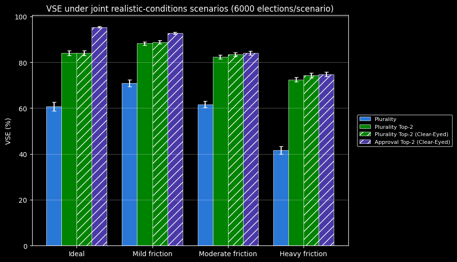

```python
# Plot and table of JUST the plurality-based methods (Plurality, Plurality Top-2, Plurality Top-2 Clear-Eyed) across the joint scenarios
plurality_labels = [l for l in COMPARE_LABELS if "Plurality" in l]
# add clear-eyed AT2 for reference
plurality_labels.append("Approval Top-2 (Clear-Eyed)")
scenario_table_and_plot(plurality_labels)
```

| Method | Ideal | Mild friction | Moderate friction | Heavy friction |
| --- | --- | --- | --- | --- |
| Plurality | 60.8% (+/-1.8) | 70.8% (+/-1.5) | 61.6% (+/-1.4) | 41.6% (+/-1.7) |
| Approval | 88.6% (+/-0.6) | 83.1% (+/-0.7) | 64.5% (+/-1.2) | 43.2% (+/-1.7) |

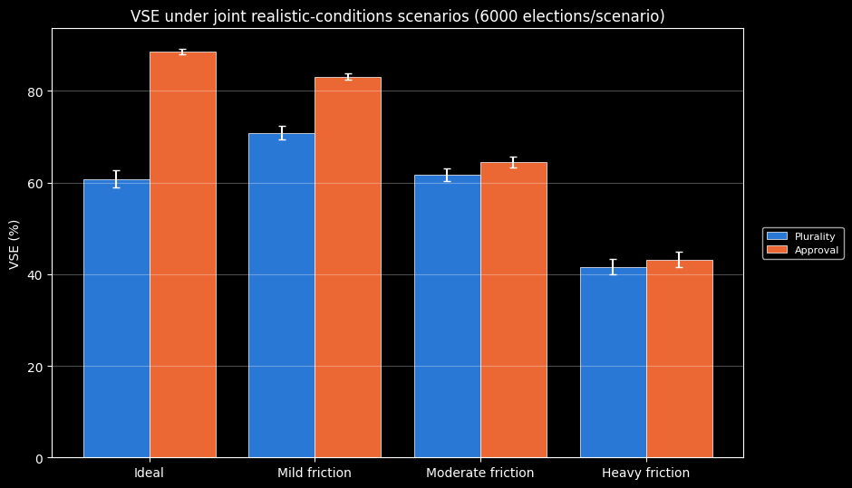

```python
# just single round plurality and approval
simple_labels = ["Plurality", "Approval"]
scenario_table_and_plot(simple_labels)
```

| Method | Ideal | Mild friction | Moderate friction | Heavy friction |
| --- | --- | --- | --- | --- |
| RCV (IRV) | 87.3% (+/-0.8) | 75.2% (+/-1.1) | 51.2% (+/-1.6) | 28.8% (+/-2.0) |
| Condorcet (Schulze) | 98.5% (+/-0.2) | 76.4% (+/-1.0) | 49.8% (+/-1.7) | 28.4% (+/-2.1) |
| Schulze (equal ranks) | 98.0% (+/-0.2) | 84.2% (+/-0.7) | 65.1% (+/-1.2) | 44.1% (+/-1.7) |
| Plurality | 60.8% (+/-1.8) | 70.8% (+/-1.5) | 61.6% (+/-1.4) | 41.6% (+/-1.7) |
| STAR | 97.1% (+/-0.3) | 83.9% (+/-0.7) | 64.8% (+/-1.2) | 43.7% (+/-1.7) |
| Approval Top-2 | 95.4% (+/-0.4) | 92.1% (+/-0.4) | 82.8% (+/-0.8) | 73.0% (+/-1.0) |

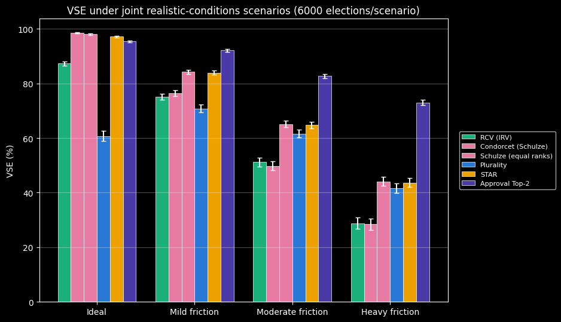

```python
# ranked methods only (RCV, Condorcet, and Condorcet with equal ranks) across the joint scenarios
ranked_labels = [l for l in COMPARE_LABELS if l in ("RCV (IRV)", "Condorcet (Schulze)", "Schulze (equal ranks)")]
# add for context: approval top-2, plurality, and STAR
ranked_labels.append("Plurality")
ranked_labels.append("STAR")
ranked_labels.append("Approval Top-2")
scenario_table_and_plot(ranked_labels)
```

| Method | Ideal | Mild friction | Moderate friction | Heavy friction |
| --- | --- | --- | --- | --- |
| Plurality | 60.8% (+/-1.8) | 70.8% (+/-1.5) | 61.6% (+/-1.4) | 41.6% (+/-1.7) |
| Approval | 88.6% (+/-0.6) | 83.1% (+/-0.7) | 64.5% (+/-1.2) | 43.2% (+/-1.7) |
| STAR | 97.1% (+/-0.3) | 83.9% (+/-0.7) | 64.8% (+/-1.2) | 43.7% (+/-1.7) |
| Plurality Top-2 | 84.1% (+/-1.1) | 88.2% (+/-0.7) | 82.3% (+/-0.8) | 72.5% (+/-1.0) |
| Approval Top-2 | 95.4% (+/-0.4) | 92.1% (+/-0.4) | 82.8% (+/-0.8) | 73.0% (+/-1.0) |

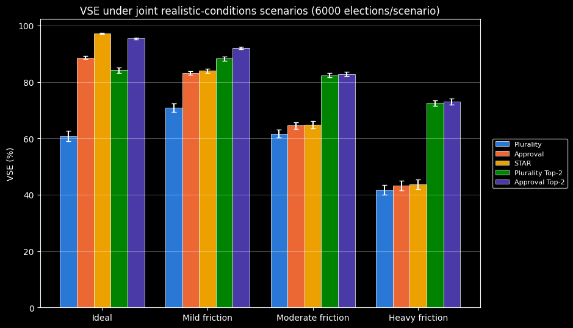

```python
# plurality, approval, star, plus top-2 variants
part_1_systems = ["Plurality", "Approval", "STAR", "Plurality Top-2", "Approval Top-2"]
scenario_table_and_plot(part_1_systems)
```

| Method | Ideal | Mild friction | Moderate friction | Heavy friction |
| --- | --- | --- | --- | --- |
| STAR | 97.1% (+/-0.3) | 83.9% (+/-0.7) | 64.8% (+/-1.2) | 43.7% (+/-1.7) |
| Approval | 88.6% (+/-0.6) | 83.1% (+/-0.7) | 64.5% (+/-1.2) | 43.2% (+/-1.7) |
| Approval Top-2 (Coma) | 95.4% (+/-0.4) | 81.6% (+/-0.8) | 56.6% (+/-1.4) | 31.6% (+/-1.9) |
| Approval Top-2 | 95.4% (+/-0.4) | 92.1% (+/-0.4) | 82.8% (+/-0.8) | 73.0% (+/-1.0) |

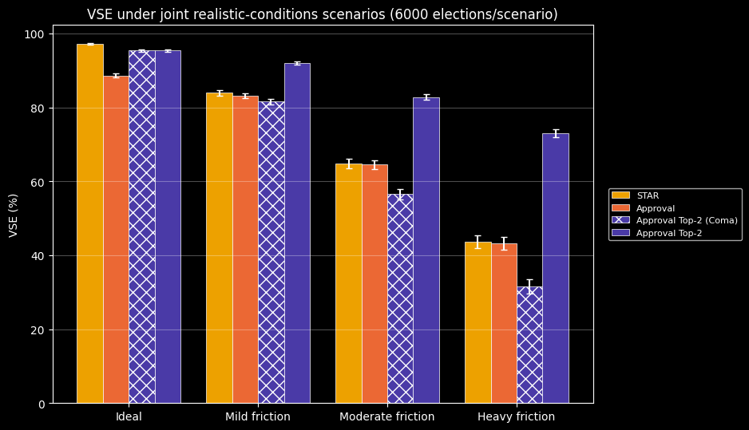

```python
## AT2 Coma vs Approval
coma_single_round_labels = ["STAR", "Approval", "Approval Top-2 (Coma)", "Approval Top-2"]
scenario_table_and_plot(coma_single_round_labels)
```